# Reference Solutions for MA119 Final Review

Author

Dr. Ye

Published

December, 2024

Abstract

Those references solutions are for MA119 final review of QCC. A pdf version can be found at https://fyeteaching.github.io/RefSolMA119/main.pdf. Please let me know if you see any mistakes. Thank you!

1. Applying negative exponent, product, quotient-to-power, product-to-power, and power-to-power rules implies
   $$\begin{aligned}
   \left(\frac{6x^5y^{-2}z}{2x^{-3}y^4z^{-11}}\right)^{-3}=&\left(\frac{3x^5x^3zz^{11}}{y^4y^2}\right)^{-3}\\
   =&\left(\frac{3x^8z^{12}}{y^6}\right)^{-3}\\
   =&\left(\frac{y^6}{3x^8z^{12}}\right)^3\\
   =&\frac{(y^6)^3}{3^3(x^8)^3(z^{12})^3}\\
   =&\frac{y^{18}}{27x^{24}z^{36}}\\
   \end{aligned}$$
2. Solving for $y$ yields $y=\frac12x-\frac74$. So the slope of the given line is $m=\frac12$. Then the slope of the perpendicular line is $m_\perp=-\frac1m=-2$. Since the perpendicular line passes through $(2,-5)$, it is determined by the equation
   $$y=-2(x-2)-5.$$
   Simplifying the right hand side yields the slope-intersect form
   $$y=-2x-1.$$
3. The slope of the given line is
   $$m=\frac{4-6}{-2-2}=\frac{-2}{-4}=\frac12.$$
   The point-slope form equation of the line is
   $$y=\frac12(x-2)+6.$$

   Simplifying the right hand side gives the slope-intercept form equation
   $$y=\frac12x+5.$$
4. The first step to solve an absolut value equation is to isolate the absolute value expression. Then using the definition of absolute value to remove the absolute value sign and solving the resulting equation. It’s better to check the answers. In this case,
   $$\begin{aligned}
   |3x+2|+1=&6\\
   |3x+2|=&5\\
   3x+2=5\quad\text{or}&\quad 3x+2=-5\\
   3x=3\quad\text{or}&\quad 3x=-7\\
   x=1\quad\text{or}&\quad x=-\frac73.
   \end{aligned}$$

   **Check:** when $x=1$, the left hand side is $|3\cdot 1 + 2|+1=|5|+1=5+1=6$ which equals the right hand side. So $x=1$ is a solution. When $x=-\frac73$, the left hand side is $|3\cdot(-\frac73)+3|+1=|-5|+1=5+1=6$ which equals the right hand side. So $x=-\frac73$ is also a solution.
5. When using grouping method to factor polynomial with four terms, you can expect the second group has the same binomial factor.

   $$\begin{aligned}
   12xy-10y-18x+15=&(12xy-10y)+(-18x+15)\\
   =&2y(6x-5)+(6x-5)(-3)\\
   =&(6x-5)(2y-3).
   \end{aligned}$$

   $$\begin{aligned}
   x^3+5x^2-16x-80=&(x^3+5x^2)+(-16x-80)\\
   =&x^2(x+5)+(x+5)(-16)\\
   =&(x+5)(x^2-16)\\
   =&(x+5)(x^2-4^2)\\
   =&(x+5)(x-4)(x+4).
   \end{aligned}$$
6. The graph has two $x$-intercepts $(-1, 0)$ and $(3,0)$ and one $y$-intercept $(0, 3)$. The graph between the two $x$-intercepts is above the $x$-axis, equivalently, $y>0$. So the $y$-value is positive if $x$ is in $(-1,3)$. The domain of the graph is $(-\infty, \infty)$ because any vertical line will intersect the graph. The range of the graph is $(-\infty, 4]$ because it has a highest positioned point $(1, 4)$ but no lowest positioned point. The value $f(1)=4$ as $(1, 4)$ is the point on the graph. Since $f(0)=3$ and $f(2)=3$, the equation $f(x)=3$ has two solutions $x=0$ and $x=2$.
7. Solving a linear inequality is very similar to solving a linear equation. But for a linear inequality, when multiplying or dividing a negative number, the inequality sign should be switched.
   $$\begin{aligned}
   4x-5\leq& 3(x+2)\\
   4x-5\leq& 3x+6\\
   x\leq&11.
   \end{aligned}$$
   As $x\leq 11$, $x$ is on the left hand side of 11. That is 11 is the right bound of the interval. There is no left bound so the interval for $x\le 11$ is $(-\infty, 11]$.
8. When factoring a binomial involving cubes, you may need the sum/difference of cubes formula $A^3\pm B^3=(A\pm B)(A^2\mp AB+B^2)$.
   $$x^3y-8y=y(x^3-8)=y(x-2)(x^2+2x+4).$$
9. As the variable appears in the denominators, and fractions undefined if the denominator is zero, the restrictions on $x$ is $x \neq 0$ **AND** $x^2 + 3x - 10 \neq 0$. Since $x^2 + 3 x - 10 = (x - 2)(x + 5)$. The restriction is equivalent to $x\neq 2$ and $x\neq -5$. Given the restriction, one way to solve the rational equation is to first clearing the denominator by multiplying the LCD. Due to the restrictions, after solving the resulting equation, the solutions must be checked. In this case, the LCD is $x^2 + 3 x - 10 = (x - 2)(x + 5)$.
   $$\begin{aligned}
   \frac{2}{x - 2}-\frac{14}{x^2 + 3x - 10}=&1\\
   (x - 2)(x + 5)\cdot \frac{2}{x - 2} - (x^2 + 3 x - 10)\cdot\frac{14}{x^2 + 3x - 10} = & x^2 + 3 x - 10\\
   2(x + 5) - 14 =& x^2 + 3 x - 10\\
   2x - 4 = & x^2 + 3 x - 10\\
   x^2 + x - 6 =&0\\
   (x - 2)(x + 3)=&0\\
   x - 2=0\quad\text{or}&\quad x + 3=0\\
   x = 2\quad\text{or}&\quad x = -3.
   \end{aligned}$$
   Since the LCD is zero for $x=2$ and nonzero for $x = -3$, only $x = -3$ is a solution.
10. For a square root to be real, the radicand has to be nonnegative. Therefore, the domain of the function $f(x)=\sqrt{-4-2x}$ is the solution set of the inequality $-4-2x\ge 0$. Solving this linear inequality implies $x\le -2$. In interval notation, the domain is $(-\infty, -2]$.
11. Since $-27=(-3)^3$, $(-27)^{\frac23}=((-3)^3)^{\frac23}=(-3)^2=9$.
12. Rational exponents have the same rules of integer exponents. Moreover, $x^{\frac mn}=\sqrt[n]{x^m}=(\sqrt[n]{x})^m$ given that $\sqrt[n]x$ is real. Then
    $$(-8x^6y^2)^{\frac13}=((-2)^3)^{\frac13}(x^6)^{\frac13}(y^2)^{\frac13}=(-2)^1x^2y^{\frac23}=-2x^2\sqrt[3]{y^2}.$$
13. Solving a radical equation is similar to solving an absolute value equation or an exponential equation. A radical expression should be isolated first. Then a functional transformation, taking power of both sides, can be applied. But be careful, not all functional transformations are equivalent transformations.
    $$\begin{aligned}
    \sqrt{2 x - 1} + 2 = & x\\
    \sqrt{2 x - 1} = & x - 2\\
    (\sqrt{2 x - 1})^2 = & (x - 2)^2\\
    2 x - 1 = & x^2 -2\cdot 2\cdot x + 2^2\\
    x^2 - 6x + 5 = & 0\\
    (x - 1)(x - 5)=&0\\
    x - 1 = 0\quad\text{or}&\quad x - 5 = 0\\
    x = 1\quad\text{or}&\quad x = 5.
    \end{aligned}$$
    **Check:** when $x=2$, the left-hand side is $\sqrt{2 \cdot 1 - 1 } + 2= 1 + 2 = 3$ while the right-hand side is 1. So $x = 1$ is not a solution. When $x = 5$, the left-hand side is $\sqrt{2 \cdot 5 - 1} + 2 = \sqrt{9} + 2 = 3 + 2 = 5$ which equals the right-hand side x=5. So $x=5$ is a solution.
14. Note that $\mathbf{i}^2=-1$ and $(A\pm B)^2=A^2\pm 2AB+B^2$. Then
    $$(3+4\mathbf{i})^2=3^2+2\cdot 3\cdot 4\mathbf{i}+4^2\mathbf{i}^2=9+24\mathbf{i}-16=-7+24\mathbf{i}.$$
15. Recall $\sqrt{-b}=\mathbf{i}\sqrt{b}$ if $b>0$. Then
    $$\begin{aligned}
    (x-7)^2=&-16\\
    x-7=&\pm\sqrt{-16}\\
    x-7=&\pm\sqrt{16}\cdot\mathbf{i}\\
    x-7=&\pm4\mathbf{i}\\
    x=&7\pm4\mathbf{i}.\\
    \end{aligned}$$
16. Suppose the width of the frame is $x$ centimeters, then the dimension of the combined area is $2x+50$ centimeters by $2x+30$ centimeters and $x$ satisfies the equation
    $$(2x+50)(2x+30)=2204.$$
    Solving this equation implies
    $$\begin{aligned}
    4x^2+160x+1500=&2204\\
    4x^2+160x-704=&0\\
    x^2+40x-176=&0\\
    (x-4)(x-44)=&0\\
    x-4=0\quad\text{ or}&\quad x+44=0\\
    x=4\quad\text{ or}&\quad x=-44.
    \end{aligned}$$
    Therefore, the width of the frame is $4$ centimeters.
17. Suppose the positive number is $x$. The sum of the number and twice of its square can be expressed as $x+2x^2$. Then $x$ satisfies the equation $x+2x^2=11.88$ which can be re-written as $2x^2+x-11.88=0$. Solving by the quadratic formula yields
    $$x=\frac{-1+\sqrt{1^2-4\cdot 2\cdot (-11.88)}}{2\cdot 2}=2.2.$$
18. In the investment formula $A=P(1+\frac{r}{n})^{nt}$, $P$ is the initial investment, $r$ is the annual interest rate, $n$ is the number of compounding in a year, $t$ is the number of years, and $A$ is the balance after $t$ years. In this case, $P=20000$, $r=5\%=0.05$, $n=4$ since the interest is compounded quarterly, that is 4 times per year. Then the balance $A$ after 4 years is
    $$A=20000\left(1+\frac{0.05}{4}\right)^{4\cdot 4}\approx 24397.79.$$
19. Recall $\log_bx$ is the number $y$ such that $b^y=x$, that is, $b^{\log_bx}=x$. To solve the equation, taking both sides as exponents of the base of the log implies
    $$\begin{aligned}
    \log_8x=&\frac43\\
    8^{\log_8x}=&8^{\frac43}\\
    x=&(2^3)^{\frac43}\\
    x=&2^4\\
    x=&16.
    \end{aligned}$$
20. By the power rule of log, $\log_b(M^p)=p\log_bM$. Applying $\log$ (or $\ln$) to a power will bring down the exponent.
    $$\begin{aligned}
    3^x=&62\\
    \log(3^x)=&\log(62)\\
    x\log(3)=&\log(62)\\
    x=&\frac{\log(62)}{\log(3)}\\
    x\approx & 3.757.
    \end{aligned}$$
21. To solve a logarithmic equation involving more than one logarithms, the first step is to rewrite them into a single logarithm using rules of logarithms.
    $$\begin{aligned}
    \log(16-20x)-\log(-x)=&2\\
    \log\left(\frac{16-20x}{-x}\right)=&2\qquad \text{quotient rule applied}\\
    \left(\frac{16-20x}{-x}\right)=&10^2\qquad \text{apply the definition}\\
    \left(\frac{20x-16}{x}\right)=&100 \qquad \text{simplify}\\
    20x-16=&100x \qquad \text{clear denominator}\\
    -80x=&16 \qquad \text{adding } -100x+16 \text{ to both sides}\\
    x=&\frac{16}{-80} \qquad \text{dividing } -80 \text{ from both sides}\\
    x=&-\frac{1}{5} \qquad \text{simplify}.
    \end{aligned}$$
    **Note:** Because the domain of a logarithmic function $y=\log_bx$ is $(0, \infty)$ instead of $(-\infty,\infty)$. There may be extraneous solutions. After solving logarithmic function, you need to check if the solution makes all logarithmic expressions well defined. In this case, when $x=-\frac15$, $16-5x=20$ and $-x=\frac15$. So both logarithmic expression are well defined and $x=-\frac15$ is not an extraneous solution.
22. The notation $f(x)$ represents the output of the function $f$ for the given input $x$. When the function is defined by an equation, to evaluate $f(a)$, simply replace $x$ by $a$ and evaluate.
    $$f(0)=0^2-7\cdot 0 +4=4.$$
    $$f(-3)=(-3)^2-7\cdot (-3) + 4=9+21+4=34.$$
    $$f(2t)=(2t)^2-7\cdot (2t) + 4=4t^2-14t+4.$$
23. The domain of a rational functions consists of all real numbers except those that make the denominator zero. In this case, the solution $x=\frac54$ of the equation $5-4x=0$ should be removed. So the domain is $x\neq\frac54$. In interval notation, $(-\infty, \frac54)\cup(\frac54,\infty)$.
24. One method to solve a linear system is to eliminate one variable first using multiplication/division and addition/subtraction. For example, to eliminate $x$, multiplying the first equation by 3 and the second the equation by 4, then taking the sum yields $3(-2y)+4(-5y)=3\cdot 16+4\cdot 1$. Simplifying and solving for $y$ implies
    $$\begin{aligned}
    3(-2y)+4(-5y)=&3\cdot 16+4\cdot 1\\
    -26y=&52\\
    y=&-2.
    \end{aligned}$$

    To get $x$, the elimination method can be used again. Or one can plug $y=-2$ into one of the equations and solve for $x$.

    Plug $y=-2$ into the first equation and solve for $x$.
    $$\begin{aligned}
    4x-2(-2)=&16\\
    4x+4=&16\\
    4x=&12\\
    x=&3.
    \end{aligned}$$

    So the solution of the system is $(3, -2)$.
25. When solving this type of compounded inequality, make sure to apply changes to all three places separated by the inequality signs.
    $$\begin{array}{rcccl}
    -12 &\le& 3x-2 &<&7\\
    -10 &\le& 3x &<&9\\
    -\frac{10}{3}&\le& x &<&3.
    \end{array}$$
    In interval notation, the solution set is $\big[-\frac{10}{3}, 3\big)$.
26. The slope $m_{\parallel}$ of the parallel line equals the slope $m$ of the given line. To get the slope of the given line, solve for $y$.
    $$\begin{aligned}
    6x-3y=&12\\
    -3y=&-6x-12\\
    y=&2x+4.
    \end{aligned}$$
    So $m_\parallel=m=2$. The point-slope form equation of the parallel line is
    $$y=2(x-2)-3.$$

    Simplifying the right hand side give the slope-intercept form equation
    $$y=2x-7.$$

    The $x$-intercept has the $y$-coordinate $0$. Let $y=0$ in the slope-intercept form and solve for $x$ yields $x=\frac72$. So the $x$-intercept is $\left(\frac{7}{2},0\right)$.
27. Since the unknown $b$ is in the denominator, to solve for $b$, we may first clearing denominators by multiplying the LCD $abc$ to both sides and then simplify and solve.
    $$\begin{aligned}
    \frac1a=&\frac1b+\frac1c\\
    abc\cdot\frac1a=&abc\cdot\frac1b+abc\cdot\frac1c\\
    bc=&ac+ab\\
    bc-ab=&ac\\
    b(c-a)=&ac\\
    b=&\frac{ac}{c-a}\quad\text{if }a\ne c.
    \end{aligned}$$
    If $a=c$, there is no solution for $b$.
28. The binomial involves cubes, the formula
    $$A^3\pm B^3=(A\pm B)(A^2\mp AB+B^2)$$
    is needed.
    $$\begin{aligned}
    &8x^6+27y^3\\
    =&(2x^2)^3+(3y)^3\\
    =&(2x^2 + 3y)((2x^2)^2-(2x^2)(3y)+(3y)^2)\\
    =&(2x^2 + 3y)(4x^4-6x^2y+9y^2).
    \end{aligned}$$
29. A complex rational expression is the quotient of a rational expression by another rational expression. One way to simplify it is to simplify both the numerator and denominator first and then convert the quotient into a multiplication.
    $$\begin{aligned}
    \frac{\frac1x-\frac1y}{1-\frac{x^2}{y^2}}
    =&\frac{\frac{y-x}{xy}}{\frac{y^2-x^2}{y^2}}\\
    =&\frac{y-x}{xy}\cdot\frac{y^2}{y^2-x^2}\\
    =&\frac{y^2(y-x)}{xy(y-x)(y+x)}\\
    =&\frac{y}{x(y+x)}.
    \end{aligned}$$
30. To evaluate $f(a)$, substitute $x$ by $a$ in the equation.
    $$f(0)=\sqrt[3]{3\cdot 0-8}=\sqrt[3]{-8}=-2.$$
    $$f(24)=\sqrt[3]{3\cdot 24-8}=\sqrt[3]{64}=4.$$
31. If the denominator is a binomial involving only square roots, multiplying both the numerator and the denominator by the conjugate will eliminate the square root signs from the denominator using the difference of squares formula $(A-B)(A+B)=A^2-B^2$.
    $$\begin{aligned}
    \frac{6}{3\sqrt{x}-2}=&\frac{6(3\sqrt{x}+2)}{(3\sqrt{x}-2)(3\sqrt{x}+2)}\\
    =&\frac{18\sqrt{x}+12}{(3\sqrt{x})^2-2^2}\\
    =&\frac{18\sqrt{x}+12}{9x-4}.
    \end{aligned}$$
32. To simplify a radical, the following formula can be used: $\sqrt[n]{x^m}=x^p\sqrt[n]{x^r}$, where $p$ is the quotient of $m$ by $n$ and $r$ is the reminder.
    $$\sqrt{24x^9y^6}=\sqrt{3\cdot 2^3x^9y^6}=2x^4y^3\sqrt{3\cdot 2 x}=2x^4y^3\sqrt{6x}.$$
33. Before combining like radicals, the radicals should be simplified first.
    $$\begin{aligned}
    2\sqrt{9}-5\sqrt3-\sqrt{75}=&2\cdot 3-5\sqrt3-\sqrt{3\cdot 5^2}\\
    =&6-5\sqrt3-5\sqrt3\\
    =&6-10\sqrt3.
    \end{aligned}$$
34. To get rid of the radical sign from an isolated radical, one can raise both sides to the power that is the index of the radical.
    $$\begin{aligned}
    \sqrt[3]{5+3x}=&-4\\
    (\sqrt[3]{5+3x})^3=&(-4)^3\\
    5+3x=&-64\\
    3x=&-69\\
    x=&-23.
    \end{aligned}$$

    **Check:** Plugging $x=-23$ into the left hand side implies $\sqrt[3]{5+3\cdot(-23)}=\sqrt[3]{-64}=-4$ which equals the right hand side. So $x=-23$ is the solution of the equation.
35. Simplifying a quotient of two complex numbers is similar to rationalize a denominator.
    $$\begin{aligned}
    \frac{5\mathbf{i}}{-2+3\mathbf{i}}=&\frac{5\mathbf{i}(-2-3\mathbf{i})}{(-2+3\mathbf{i})(-2-3\mathbf{i})}\\
    =&\frac{-10\mathbf{i}-15\mathbf{i}^2}{(-2)^2-(3\mathbf{i})^2}\\
    =&\frac{-10\mathbf{i}+15}{4+9}\\
    =&\frac{15}{13}-\frac{10}{13}\mathbf{i}.
    \end{aligned}$$
36. The $ax^2+bx+c=0$ can be completed into the perfect square form $a(x-h)^2+k=0$, where $h=-\frac{b}{2a}$ and $k=ah^2+bh+c$. In this case, since $a=1$ and $b=-6$, $h=-\frac{-6}{2\cdot 1}=3$ and $k=3^2-6\cdot 3+3=-6$. Therefore,
    $$\begin{aligned}
    x^2-6x+3=&0\\
    (x-3)^2-6=&0\\
    (x-3)^2=&6\\
    x-3=&\pm\sqrt{6}\\
    x=&3\pm\sqrt{6}.
    \end{aligned}$$
37. Suppose the longer leg is $x$ feet, the shorter leg is then $x-4$ feet. By the Pythagorean theorem, that is, in a right triangle, $\text{leg}^2+\text{leg}^2=\text{hypotenuse}^2$. Then the unknown $x$ satisfies the following equation:
    $$x^2+(x-4)^2=7^2.$$
    To get $x$, simplify and solve the equation. Recall that $(A\pm B)^2=A^2\pm 2AB+B^2$ and the quadratic formula $x=\frac{-b\pm\sqrt{b^2-4ac}}{2a}$ if $ax^2+bx+c=0$.
    $$\begin{aligned}
    x^2+(x-4)^2=&7^2\\
    x^2+x^2-2\cdot 4x+4^2=&49\\
    2x^2-8x+16=&49\\
    2x^2-8x-33=&0\\
    x=&\frac{-(-8)\pm\sqrt{(-8)^2-4\cdot2\cdot(-33)}}{2\cdot 2}\\
    x\approx -2.53\quad\text{or}&\quad x\approx 6.53.
    \end{aligned}$$
    Therefore, the longer leg is approximately $6.53$ feet and the shorter leg is approximately $6.53-4=2.53$ feet.
38. The $x$-intercepts have the $y$-coordinate $0$. To get their $x$-coordinates, solve the equation $-x^2+4x+5=0$.
    $$\begin{aligned}
    -x^2+4x+5=&0\\
    x^2-4x-5=&0\\
    (x+1)(x-5)=&0\\
    x+1=0\quad\text{or}&\quad x-5=0\\
    x=-1\quad\text{or}&\quad x=5.
    \end{aligned}$$
    So the $x$-intercepts are $(-1, 0)$ and $(5, 0)$.

    The $y$-intercept is $(0, f(0))=(0, c)=(0, 5)$.

    The equation of the axis of symmetry is $x=-\frac{b}{2a}$ Since $-\frac{b}{2a}=-\frac{4}{2\cdot(-1)}=2$, the axis of symmetry is $x=2$.

    The vertex is the intersection of the axis of symmetry and the parabola. So the coordinates are $\left(-\frac{b}{2a}, f\left(-\frac{b}{2a}\right)\right)$. Since $-\frac{b}{2a}=2$ and $f(2)=-2^2+4\cdot 2+5=9$, the vertex is $(2, 9)$.

    To sketch the graph, plot the intercepts, the vertex, graph the axis of symmetry and connect the points smoothly so that the graph is symmetric with respect to the axis of symmetry.

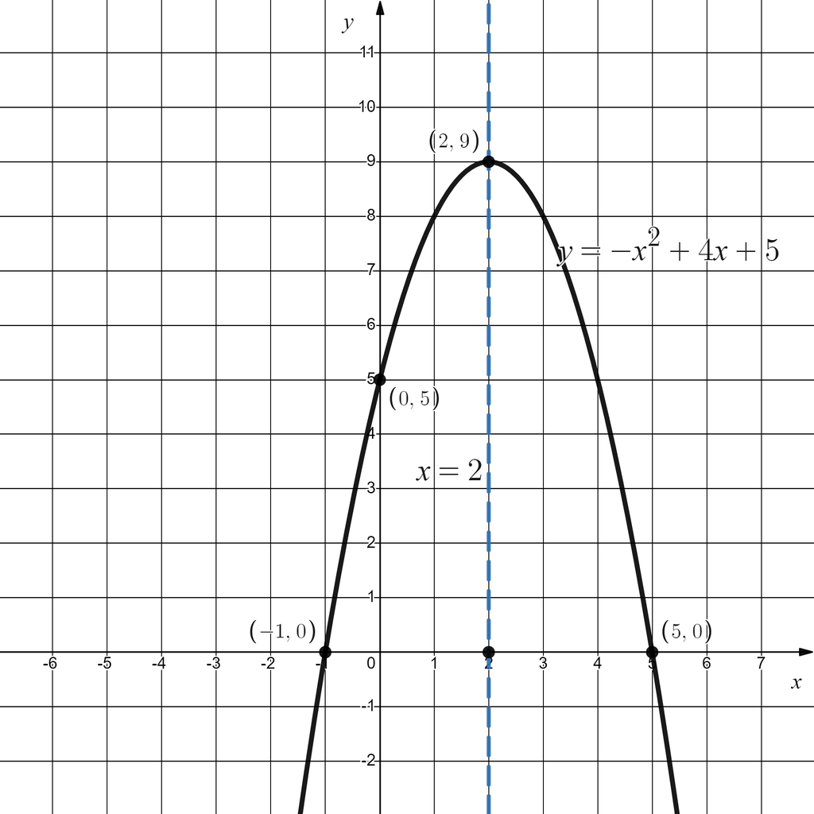

    Graph of $y=-x^2+4x+5$

39. Since $x=5.5$, the value of $V$ is
    $$V=35000\cdot (3.21)^{-0.05\cdot 5.5}\approx 25396.81.$$
40. To solve a logarithmic equation, first combine the logarithmic expressions into a single logarithm using rules of logarithms, then using the definition of logarithm to rewrite into an equivalent equation without logarithms.
    $$\begin{aligned}
    \log_4x+\log_4(x-6)=&2\\
    \log_4[x(x-6)]=&2\\
    x(x-6)=&4^2\\
    x^2-6x=&16\\
    x^2-6x-16=&0\\
    (x+2)(x-8)=&0\\
    x+2=0\quad\text{or}&\quad x-8=0\\
    x=-2\quad\text{or}&\quad x=8.
    \end{aligned}$$
    Since $\log_4(-2)$ is undefined, only $x=8$ is a solution.
41. The statement that the balance is doubled means $A=2P$. The years $t$ it takes to double the investment is then satisfies the equation $2P=P\left(1+\frac{r}{n}\right)^{nt}$. Dividing $P$ from both sides yields $2=\left(1+\frac{r}{n}\right)^{nt}$. Since $r=4.5\%=0.045$, $n=2$, the equation becomes
    $$\begin{aligned}
    2=&\left(1+\frac{0.045}{2}\right)^{2t}\\
    \log 2=&\log\left(1+\frac{0.045}{2}\right)\cdot (2t)\\
    t=&\frac{\log 2}{2\log\left(1+\frac{0.045}{2}\right)}\\
    t\approx&15.58.
    \end{aligned}$$
    So it takes approximately 15.58 years to double the balance if the interest rate is 4.5% and compounded semiannually.
42. When adding/subtracting rational expressions, the rational expressions should be rewritten into equivalent expressions with the LCD as the denominators.
    $$\begin{aligned}
    &\frac{4x-4}{x^2+2x-15}-\frac{3}{x+5}\\
    =&\frac{4x-4}{(x-3)(x+5)}-\frac{3(x-3)}{(x-3)(x+5)}\\
    =&\frac{(4x-4)-3(x-3)}{(x-3)(x+5)}\\
    =&\frac{4x-4-3x+9}{(x-3)(x+5)}\\
    =&\frac{x+5}{(x-3)(x+5)}\\
    =&\frac{1}{x-3}.
    \end{aligned}$$
43. The division of rational expressions can be rewritten as a product.
    $$\begin{aligned}
    &\frac{x^2-x-12}{2x+8}\div\frac{2x^2+5x-3}{8x-4}\\
    =&\frac{x^2-x-12}{2x+8}\cdot\frac{8x-4}{2x^2+5x-3}\\
    =&\frac{(x+3)(x-4)}{2(x+4)}\cdot\frac{4(2x-1)}{(2x-1)(x+3)}\\
    =&\frac{2(x-4)}{x+4}.
    \end{aligned}$$
44. In the equation that defines the function, we know that $R=60000$. Then $x$ satisfies the equation $60000=x(1000-4x)$. Solving the equation yields
    $$\begin{aligned}
    60000=&1000x-4x^2\\
    4x^2-1000x+60000=&0\\
    (4x-600)(x-100)=&0\\
    4x-600=0\quad\text{or}&\quad x-100=0\\
    x=150\quad\text{or}&\quad x=100.
    \end{aligned}$$
    Therefore, when 100 or 150 products were sold, the revenue is 60000.
45. When the value is $20000$, the age $x$ satisfies the equation $20000=40000(1.23)^{-0.4x}$. Solving the equation yields
    $$\begin{aligned}
    20000=&40000(1.23)^{-0.4x}\\
    0.5=&(1.23)^{-0.4x}\\
    \log(0.5)=&\log((1.23)^{-0.4x})\\
    \log(0.5)=&\log(1.23)\cdot(-0.4x)\\
    x=&\frac{\log(0.5)}{-0.4\cdot\log(1.23)}\\
    x\approx&8.37.
    \end{aligned}$$
    When the car is 8.37 years old, the value of the car becomes 20000.
46. In terms of the variables of the function, that a person weighs 80 kilogram means $x=80$. Then the calories the person needed is
    $$f(80)=70\cdot(80)^{3/4}\approx 1872.47.$$

    To mark the point, $(80, f(80))$, draw a vertical line through $80$, the intersection of the vertical line with the graph is the point on the graph.

    Suppose the person needed 1500 calories weighs $x$ kilogram, then $f(x)=1500$, that is $70\cdot x^{3/4}=1500$. Solving the equation yields
    $$\begin{aligned}
    70\cdot x^{3/4}=&1500\\
    x^{3/4}=&\frac{150}{7}\\
    (x^{3/4})^4=&(\frac{150}{7})^4\\
    x^3=&(\frac{150}{7})^4\\
    x=&\sqrt[3]{(\frac{150}{7})^4}\\
    x=&(\frac{150}{7})^{4/3}\\
    x\approx & 59.52\\
    \end{aligned}$$
    A person weighs 59.52 kilogram needs approximately 1500 calories per day.